# Customer Service Requests Analysis

## =========================Project 1=======================

## =========================By Suleyman Muhammed====================

## DESCRIPTION

### Background of Problem Statement :

```
NYC 311's mission is to provide the public with quick and easy access to all New York City government services and
information while offering the best customer service. Each day, NYC311 receives thousands of requests related to
several hundred types of non-emergency services, including noise complaints, plumbing issues, and illegally parked
cars. These requests are received by NYC311 and forwarded to the relevant agencies such as the police, buildings, or
transportation. The agency responds to the request, addresses it, and then closes it.
```

### Problem Objective :

```
Perform a service request data analysis of New York City 311 calls. You will focus on the data wrangling techniques
to understand the pattern in the data and also visualize the major complaint types.
Domain: Customer Service
```

### Analysis Tasks to be performed:

(Perform a service request data analysis of New York City 311 calls)

1. Import a 311 NYC service request.
2. Read or convert the columns ‘Created Date’ and Closed Date’ to datetime datatype and create a new column ‘Request_Closing_Time’ as the time elapsed between request creation and request closing. (Hint: Explore the package/module datetime)
3. Provide major insights/patterns that you can offer in a visual format (graphs or tables); at least 4 major conclusions that you can come up with after generic data mining.
4. Order the complaint types based on the average ‘Request_Closing_Time’, grouping them for different locations.
5. Perform a statistical test for the following: Please note: For the below statements you need to state the Null and Alternate and then provide a statistical test to accept or reject the Null Hypothesis along with the corresponding ‘p-value’.

   ```
    - Whether the average response time across complaint types is similar or not (overall)
    - Are the type of complaint or service requested and location related?
   ```

### Dataset Description :

```
   Field                                                Description
```

- Unique Key (Plain text) - Unique identifier for the complaints
- Created Date (Date and Time) - The date and time on which the complaint is raised
- Closed Date (Date and Time) - The date and time on which the complaint is closed
- Agency (Plain text) - Agency code
- Agency Name (Plain text) - Name of the agency
- Complaint Type (Plain text) - Type of the complaint
- Descriptor (Plain text) - Complaint type label (Heating - Heat, Traffic Signal Condition -

  ```
                                     Controller)
  ```

- Location Type (Plain text) - Type of the location (Residential, Restaurant, Bakery, etc)
- Incident Zip (Plain text) - Zip code for the location
- Incident Address (Plain text) - Address of the location
- Street Name (Plain text) - Name of the street
- Cross Street 1 (Plain text) - Detail of cross street
- Cross Street 2 (Plain text) - Detail of another cross street
- Intersection Street 1 (Plain text) - Detail of intersection street if any
- Intersection Street 2 (Plain text) - Detail of another intersection street if any
- Address Type (Plain text) - Categorical (Address or Intersection)
- City (Plain text) - City for the location
- Landmark (Plain text) - Empty field
- Facility Type (Plain text) - N/A
- Status (Plain text) - Categorical (Closed or Pending)
- Due Date (Date and Time) - Date and time for the pending complaints
- Resolution Action Updated Date (Date and Time) - Date and time when the resolution was provided
- Community Board (Plain text) - Categorical field (specifies the community board with its code)
- Borough (Plain text) - Categorical field (specifies the community board)
- X Coordinate (State Plane) (Number)
- Y Coordinate (State Plane) (Number)
- Park Facility Name (Plain text) - Unspecified
- Park Borough (Plain text) - Categorical (Unspecified, Queens, Brooklyn etc)
- School Name (Plain text) - Unspecified
- School Number (Plain text) - Unspecified
- School Region (Plain text) - Unspecified
- School Code (Plain text) - Unspecified
- School Phone Number (Plain text) - Unspecified
- School Address (Plain text) - Unspecified
- School City (Plain text) - Unspecified
- School State (Plain text) - Unspecified
- School Zip (Plain text) - Unspecified
- School Not Found (Plain text) - Empty Field
- School or Citywide Complaint (Plain text) - Empty Field
- Vehicle Type (Plain text) - Empty Field
- Taxi Company Borough (Plain text) - Empty Field
- Taxi Pick Up Location (Plain text) - Empty Field
- Bridge Highway Name (Plain text) - Empty Field
- Bridge Highway Direction (Plain text) - Empty Field
- Road Ramp (Plain text) - Empty Field
- Bridge Highway Segment (Plain text) - Empty Field
- Garage Lot Name (Plain text) - Empty Field
- Ferry Direction (Plain text) - Empty Field
- Ferry Terminal Name (Plain text) - Empty Field
- Latitude (Number) - Latitude of the location
- Longitude (Number) - Longitude of the location

```python
import pandas as pd
import numpy as np
import scipy.stats as stats
import matplotlib.pyplot as plt
from matplotlib import style
import seaborn as sns
import warnings
```

# Step 1

```
- Importing the dataset
```

```python
df = pd.read_csv('C:\\Users\\ayman\\Desktop\\DataScience\\Data Science with Python Two\\Cutomer_Service_Request_Analysis_from_2010_to_Present.csv', low_memory=False)
```

```python
# View the first 10 rows of the dataset
df.head(10)
```

|  | Unique Key | Created Date | Closed Date | Agency | Agency Name | Complaint Type | Descriptor | Location Type | Incident Zip | Incident Address | ... | Bridge Highway Name | Bridge Highway Direction | Road Ramp | Bridge Highway Segment | Garage Lot Name | Ferry Direction | Ferry Terminal Name | Latitude | Longitude | Location |
| --- | --- | --- | --- | --- | --- | --- | --- | --- | --- | --- | --- | --- | --- | --- | --- | --- | --- | --- | --- | --- | --- |
| 0 | 32310363 | 12/31/2015 11:59:45 PM | 01-01-16 0:55 | NYPD | New York City Police Department | Noise - Street/Sidewalk | Loud Music/Party | Street/Sidewalk | 10034.0 | 71 VERMILYEA AVENUE | ... | NaN | NaN | NaN | NaN | NaN | NaN | NaN | 40.865682 | -73.923501 | (40.86568153633767, -73.92350095571744) |
| 1 | 32309934 | 12/31/2015 11:59:44 PM | 01-01-16 1:26 | NYPD | New York City Police Department | Blocked Driveway | No Access | Street/Sidewalk | 11105.0 | 27-07 23 AVENUE | ... | NaN | NaN | NaN | NaN | NaN | NaN | NaN | 40.775945 | -73.915094 | (40.775945312321085, -73.91509393898605) |
| 2 | 32309159 | 12/31/2015 11:59:29 PM | 01-01-16 4:51 | NYPD | New York City Police Department | Blocked Driveway | No Access | Street/Sidewalk | 10458.0 | 2897 VALENTINE AVENUE | ... | NaN | NaN | NaN | NaN | NaN | NaN | NaN | 40.870325 | -73.888525 | (40.870324522111424, -73.88852464418646) |
| 3 | 32305098 | 12/31/2015 11:57:46 PM | 01-01-16 7:43 | NYPD | New York City Police Department | Illegal Parking | Commercial Overnight Parking | Street/Sidewalk | 10461.0 | 2940 BAISLEY AVENUE | ... | NaN | NaN | NaN | NaN | NaN | NaN | NaN | 40.835994 | -73.828379 | (40.83599404683083, -73.82837939584206) |
| 4 | 32306529 | 12/31/2015 11:56:58 PM | 01-01-16 3:24 | NYPD | New York City Police Department | Illegal Parking | Blocked Sidewalk | Street/Sidewalk | 11373.0 | 87-14 57 ROAD | ... | NaN | NaN | NaN | NaN | NaN | NaN | NaN | 40.733060 | -73.874170 | (40.733059618956815, -73.87416975810375) |
| 5 | 32306554 | 12/31/2015 11:56:30 PM | 01-01-16 1:50 | NYPD | New York City Police Department | Illegal Parking | Posted Parking Sign Violation | Street/Sidewalk | 11215.0 | 260 21 STREET | ... | NaN | NaN | NaN | NaN | NaN | NaN | NaN | 40.660823 | -73.992568 | (40.66082272389114, -73.99256786342693) |
| 6 | 32306559 | 12/31/2015 11:55:32 PM | 01-01-16 1:53 | NYPD | New York City Police Department | Illegal Parking | Blocked Hydrant | Street/Sidewalk | 10032.0 | 524 WEST 169 STREET | ... | NaN | NaN | NaN | NaN | NaN | NaN | NaN | 40.840848 | -73.937375 | (40.840847591440415, -73.9373750864581) |
| 7 | 32307009 | 12/31/2015 11:54:05 PM | 01-01-16 1:42 | NYPD | New York City Police Department | Blocked Driveway | No Access | Street/Sidewalk | 10457.0 | 501 EAST 171 STREET | ... | NaN | NaN | NaN | NaN | NaN | NaN | NaN | 40.837503 | -73.902905 | (40.83750262540012, -73.90290517326568) |
| 8 | 32308581 | 12/31/2015 11:53:58 PM | 01-01-16 8:27 | NYPD | New York City Police Department | Illegal Parking | Posted Parking Sign Violation | Street/Sidewalk | 11415.0 | 83-44 LEFFERTS BOULEVARD | ... | NaN | NaN | NaN | NaN | NaN | NaN | NaN | 40.704977 | -73.832605 | (40.704977164399935, -73.8326047502584) |
| 9 | 32308391 | 12/31/2015 11:53:58 PM | 01-01-16 1:17 | NYPD | New York City Police Department | Blocked Driveway | No Access | Street/Sidewalk | 11219.0 | 1408 66 STREET | ... | NaN | NaN | NaN | NaN | NaN | NaN | NaN | 40.623793 | -73.999539 | (40.623793065806524, -73.99953890121567) |

10 rows × 53 columns

```python
# shape-up the dataset to understand
df.shape
```

```
(300698, 53)
```

```python
# The columns' data info
df.info()
```

```
<class 'pandas.core.frame.DataFrame'>
RangeIndex: 300698 entries, 0 to 300697
Data columns (total 53 columns):
 #   Column                          Non-Null Count   Dtype
---  ------                          --------------   -----
 0   Unique Key                      300698 non-null  int64
 1   Created Date                    300698 non-null  object
 2   Closed Date                     298534 non-null  object
 3   Agency                          300698 non-null  object
 4   Agency Name                     300698 non-null  object
 5   Complaint Type                  300698 non-null  object
 6   Descriptor                      294784 non-null  object
 7   Location Type                   300567 non-null  object
 8   Incident Zip                    298083 non-null  float64
 9   Incident Address                256288 non-null  object
```

[output cut: 45 more lines]

```python
# Type of complaints
df['Complaint Type'].unique()
```

```
array(['Noise - Street/Sidewalk', 'Blocked Driveway', 'Illegal Parking',
       'Derelict Vehicle', 'Noise - Commercial',
       'Noise - House of Worship', 'Posting Advertisement',
       'Noise - Vehicle', 'Animal Abuse', 'Vending', 'Traffic',
       'Drinking', 'Bike/Roller/Skate Chronic', 'Panhandling',
       'Noise - Park', 'Homeless Encampment', 'Urinating in Public',
       'Graffiti', 'Disorderly Youth', 'Illegal Fireworks',
       'Ferry Complaint', 'Agency Issues', 'Squeegee', 'Animal in a Park'],
      dtype=object)
```

```python
# Descriptor
df['Descriptor'].unique()
```

```
array(['Loud Music/Party', 'No Access', 'Commercial Overnight Parking',
       'Blocked Sidewalk', 'Posted Parking Sign Violation',
       'Blocked Hydrant', 'With License Plate', 'Partial Access',
       'Unauthorized Bus Layover', 'Double Parked Blocking Vehicle',
       'Double Parked Blocking Traffic', 'Vehicle', 'Loud Talking',
       'Banging/Pounding', 'Car/Truck Music', 'Tortured',
       'In Prohibited Area', 'Congestion/Gridlock', 'Neglected',
       'Car/Truck Horn', 'In Public', 'Other (complaint details)', nan,
       'No Shelter', 'Truck Route Violation', 'Unlicensed',
       'Overnight Commercial Storage', 'Engine Idling',
       'After Hours - Licensed Est', 'Detached Trailer',
       'Underage - Licensed Est', 'Chronic Stoplight Violation',
       'Loud Television', 'Chained', 'Building', 'In Car',
       'Police Report Requested', 'Chronic Speeding',
       'Playing in Unsuitable Place', 'Drag Racing',
       'Police Report Not Requested', 'Nuisance/Truant', 'Homeless Issue',
       'Language Access Complaint', 'Disruptive Passenger',
       'Animal Waste'], dtype=object)
```

```python
# Complaints' count by city
complaints_type_by_city = pd.DataFrame({'count':df.groupby(['Complaint Type','City']).size()}).reset_index()
complaints_type_by_city
```

|  | Complaint Type | City | count |
| --- | --- | --- | --- |
| 0 | Animal Abuse | ARVERNE | 38 |
| 1 | Animal Abuse | ASTORIA | 125 |
| 2 | Animal Abuse | BAYSIDE | 37 |
| 3 | Animal Abuse | BELLEROSE | 7 |
| 4 | Animal Abuse | BREEZY POINT | 2 |
| ... | ... | ... | ... |
| 759 | Vending | STATEN ISLAND | 25 |
| 760 | Vending | SUNNYSIDE | 15 |
| 761 | Vending | WHITESTONE | 1 |
| 762 | Vending | WOODHAVEN | 6 |
| 763 | Vending | WOODSIDE | 15 |

764 rows × 3 columns

```python
df.groupby(['Borough','Complaint Type','Descriptor']).size()
```

```
Borough      Complaint Type         Descriptor
BRONX        Animal Abuse           Chained                      132
                                    In Car                        36
                                    Neglected                    673
                                    No Shelter                    71
                                    Other (complaint details)    311
                                                                ...
Unspecified  Noise - Vehicle        Engine Idling                 11
             Posting Advertisement  Vehicle                        1
             Traffic                Truck Route Violation          1
             Vending                In Prohibited Area             2
                                    Unlicensed                     5
Length: 288, dtype: int64
```

```python
# Check for duplications
df.duplicated().sum()
```

```
0
```

```python
df.isna().sum()
```

```
Unique Key                             0
Created Date                           0
Closed Date                         2164
Agency                                 0
Agency Name                            0
Complaint Type                         0
Descriptor                          5914
Location Type                        131
Incident Zip                        2615
Incident Address                   44410
Street Name                        44410
Cross Street 1                     49279
Cross Street 2                     49779
Intersection Street 1             256840
Intersection Street 2             257336
Address Type                        2815
City                                2614
Landmark                          300349
Facility Type                       2171
Status                                 0
Due Date                               3
Resolution Description                 0
Resolution Action Updated Date      2187
Community Board                        0
Borough                                0
X Coordinate (State Plane)          3540
Y Coordinate (State Plane)          3540
Park Facility Name                     0
Park Borough                           0
School Name                            0
School Number                          0
School Region                          1
School Code                            1
School Phone Number                    0
School Address                         0
School City                            0
School State                           0
School Zip                             1
School Not Found                       0
School or Citywide Complaint      300698
Vehicle Type                      300698
Taxi Company Borough              300698
Taxi Pick Up Location             300698
Bridge Highway Name               300455
Bridge Highway Direction          300455
Road Ramp                         300485
Bridge Highway Segment            300485
Garage Lot Name                   300698
Ferry Direction                   300697
Ferry Terminal Name               300696
Latitude                            3540
Longitude                           3540
Location                            3540
dtype: int64
```

```python
# Drop the Not applicable values
df.dropna(subset=['City','Latitude'],inplace=True)
```

```python
df.to_csv('Nyc_Customer_Cleaned.csv',index=False)
```

# Step 2

```
- Convert and read the date represented columns to date datatype
- And Check the elapsed time between the Created and Closed date by
  creating a new column
```

```python
import datetime
```

```python
df=pd.read_csv('C:\\Users\\ayman\\Desktop\\DataScience\\Data Science with Python Two\\Cutomer_Service_Request_Analysis_from_2010_to_Present.csv', parse_dates=["Created Date","Closed Date"], low_memory=False)
```

```python
df["Closing_time"] = df["Closed Date"] - df["Created Date"]
```

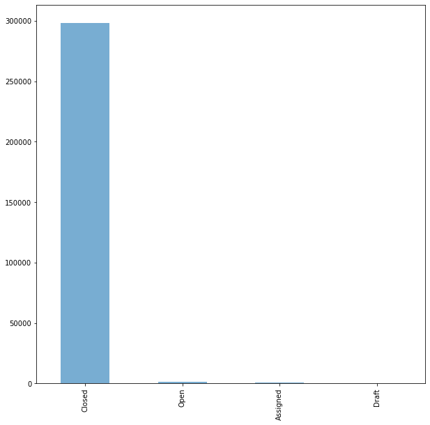

```python
df['Status'].value_counts().plot(kind='bar',alpha=0.6,figsize=(10,10))
plt.show()
```

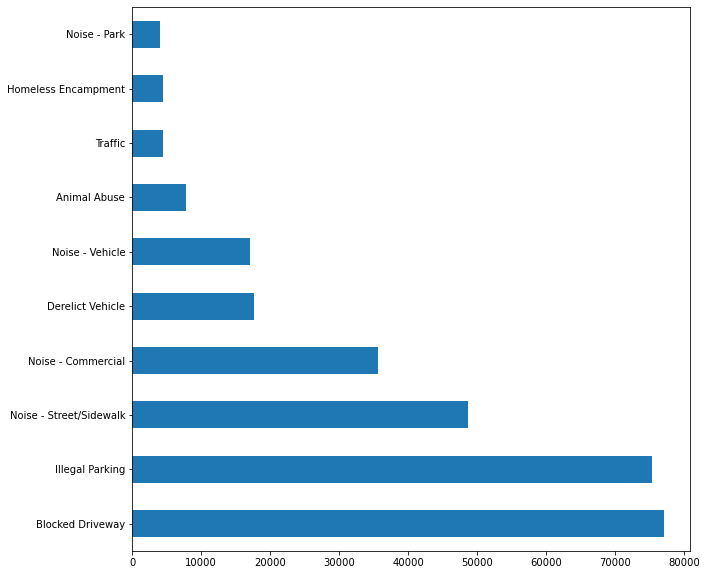

```python
# Break down the types of complaints so it will be easy to find out most of the complaints type
df['Complaint Type'].value_counts().head(10).plot(kind='barh',figsize=(10,10))
```

```python
# Calculating the Request Closing time to minutes
df['Closing_time_min'] = df['Closing_time']/np.timedelta64(1,'m')
```

```python
df.head()
```

|  | Unique Key | Created Date | Closed Date | Agency | Agency Name | Complaint Type | Descriptor | Location Type | Incident Zip | Incident Address | ... | Road Ramp | Bridge Highway Segment | Garage Lot Name | Ferry Direction | Ferry Terminal Name | Latitude | Longitude | Location | Closing_time | Closing_time_min |
| --- | --- | --- | --- | --- | --- | --- | --- | --- | --- | --- | --- | --- | --- | --- | --- | --- | --- | --- | --- | --- | --- |
| 0 | 32310363 | 2015-12-31 23:59:45 | 2016-01-01 00:55:00 | NYPD | New York City Police Department | Noise - Street/Sidewalk | Loud Music/Party | Street/Sidewalk | 10034.0 | 71 VERMILYEA AVENUE | ... | NaN | NaN | NaN | NaN | NaN | 40.865682 | -73.923501 | (40.86568153633767, -73.92350095571744) | 0 days 00:55:15 | 55.250000 |
| 1 | 32309934 | 2015-12-31 23:59:44 | 2016-01-01 01:26:00 | NYPD | New York City Police Department | Blocked Driveway | No Access | Street/Sidewalk | 11105.0 | 27-07 23 AVENUE | ... | NaN | NaN | NaN | NaN | NaN | 40.775945 | -73.915094 | (40.775945312321085, -73.91509393898605) | 0 days 01:26:16 | 86.266667 |
| 2 | 32309159 | 2015-12-31 23:59:29 | 2016-01-01 04:51:00 | NYPD | New York City Police Department | Blocked Driveway | No Access | Street/Sidewalk | 10458.0 | 2897 VALENTINE AVENUE | ... | NaN | NaN | NaN | NaN | NaN | 40.870325 | -73.888525 | (40.870324522111424, -73.88852464418646) | 0 days 04:51:31 | 291.516667 |
| 3 | 32305098 | 2015-12-31 23:57:46 | 2016-01-01 07:43:00 | NYPD | New York City Police Department | Illegal Parking | Commercial Overnight Parking | Street/Sidewalk | 10461.0 | 2940 BAISLEY AVENUE | ... | NaN | NaN | NaN | NaN | NaN | 40.835994 | -73.828379 | (40.83599404683083, -73.82837939584206) | 0 days 07:45:14 | 465.233333 |
| 4 | 32306529 | 2015-12-31 23:56:58 | 2016-01-01 03:24:00 | NYPD | New York City Police Department | Illegal Parking | Blocked Sidewalk | Street/Sidewalk | 11373.0 | 87-14 57 ROAD | ... | NaN | NaN | NaN | NaN | NaN | 40.733060 | -73.874170 | (40.733059618956815, -73.87416975810375) | 0 days 03:27:02 | 207.033333 |

5 rows × 55 columns

```python
# Compliants Types grouped by
df.groupby(["Borough","Complaint Type","Descriptor"]).size()
```

```
Borough        Complaint Type  Descriptor
BRONX          Animal Abuse    Chained                      132
                               In Car                        36
                               Neglected                    672
                               No Shelter                    71
                               Other (complaint details)    311
                                                           ...
STATEN ISLAND  Traffic         Congestion/Gridlock          113
                               Drag Racing                   18
                               Truck Route Violation         13
               Vending         In Prohibited Area             5
                               Unlicensed                    20
Length: 248, dtype: int64
```

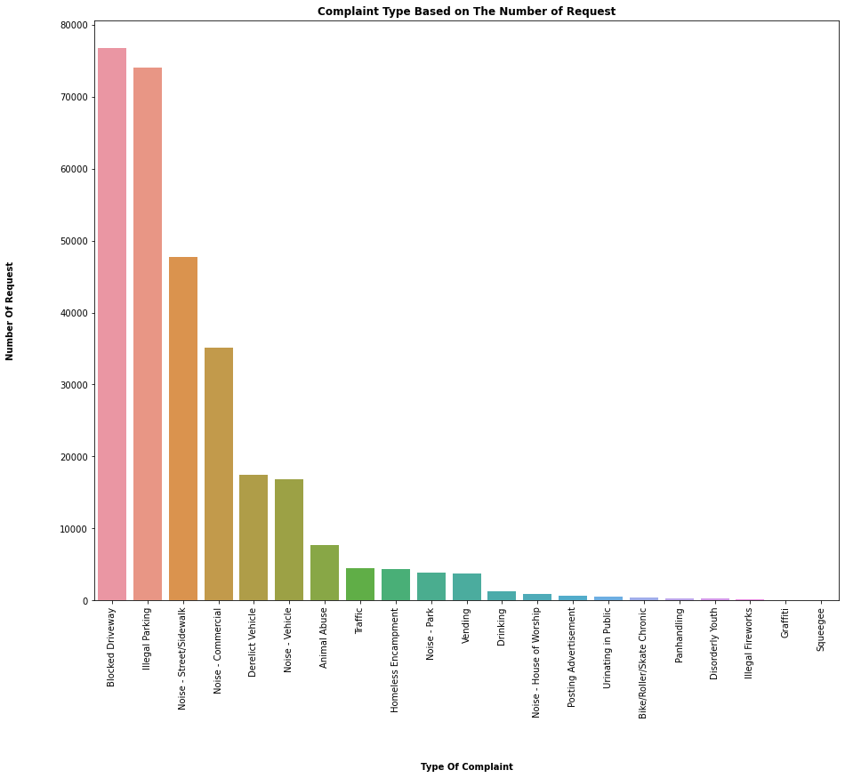

```python
# Now Complaint type depend on the number of request
df['City']= df['City'].str.lower().str.replace(" ","_")
txt={'weight':'bold'}
plt.figure(figsize=(15,12))
sns.countplot(x='Complaint Type',data=df,order=df['Complaint Type'].value_counts().index)
plt.xticks(rotation=90)
plt.title("Complaint Type Based on The Number of Request",fontdict=txt)
plt.xlabel('Type Of Complaint',fontdict=txt,labelpad=50)
plt.ylabel('Number Of Request',fontdict=txt,labelpad=50)
plt.show()
```

```python
highComplaints = df.dropna(subset=["Complaint Type"])
highComplaints = df.groupby("Complaint Type")
# Sort the complaint type
complaintTypeSorted = highComplaints.size().sort_values(ascending = False)
complaintTypeSorted = complaintTypeSorted.to_frame('Number of Complaint').reset_index()

complaintTypeSorted
complaintTypeSorted.head(20)
```

|  | Complaint Type | Number of Complaint |
| --- | --- | --- |
| 0 | Blocked Driveway | 76722 |
| 1 | Illegal Parking | 74063 |
| 2 | Noise - Street/Sidewalk | 47770 |
| 3 | Noise - Commercial | 35165 |
| 4 | Derelict Vehicle | 17519 |
| 5 | Noise - Vehicle | 16873 |
| 6 | Animal Abuse | 7747 |
| 7 | Traffic | 4473 |
| 8 | Homeless Encampment | 4366 |
| 9 | Noise - Park | 3929 |
| 10 | Vending | 3776 |
| 11 | Drinking | 1271 |
| 12 | Noise - House of Worship | 922 |
| 13 | Posting Advertisement | 649 |
| 14 | Urinating in Public | 592 |
| 15 | Bike/Roller/Skate Chronic | 414 |
| 16 | Panhandling | 301 |
| 17 | Disorderly Youth | 285 |
| 18 | Illegal Fireworks | 163 |
| 19 | Graffiti | 113 |

# Step 3

### Conclusion for the Following Complaints:

##### - Number of Complaints by City

##### - Responce time for the Complaints (Average vs Maximum) and (Minimum vs Maximum)

##### - Which Complaints are Responded quick & which ones are not

##### - Number of Complaints Requests by Complaint Type

##### - Number of Complaints Type by City

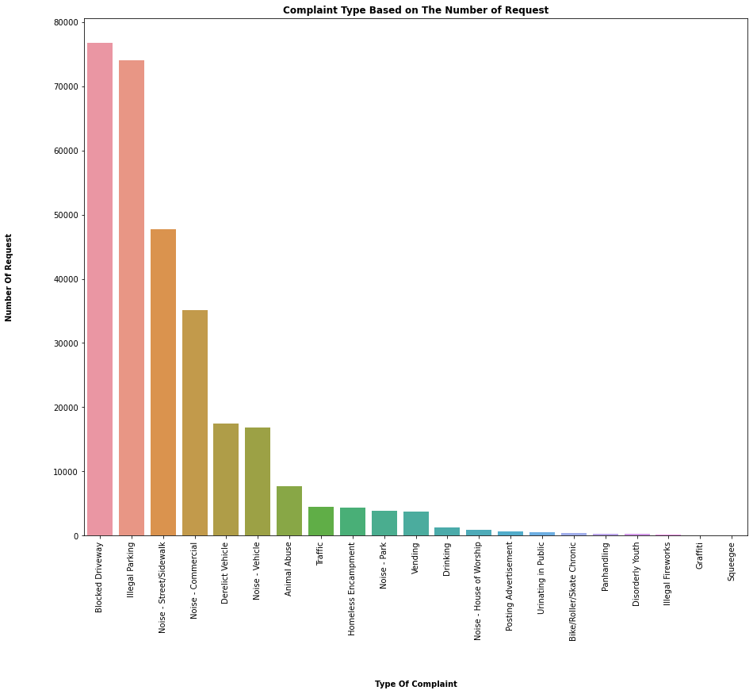

```python
df['City']= df['City'].str.lower().str.replace(" ","_")
txt={'weight':'bold'}
plt.figure(figsize=(15,12))
sns.countplot(x='Complaint Type',data=df,order=df['Complaint Type'].value_counts().index)
plt.xticks(rotation=90)
plt.title("Complaint Type Based on The Number of Request",fontdict=txt)
plt.xlabel('Type Of Complaint',fontdict=txt,labelpad=50)
plt.ylabel('Number Of Request',fontdict=txt,labelpad=50)
plt.show()
```

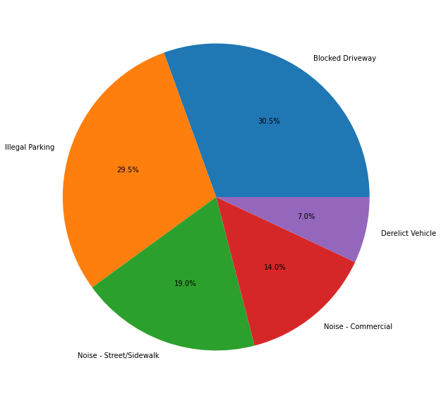

```python
complaintTypeSorted = complaintTypeSorted.head()
plt.figure(figsize=(10,10))
plt.pie(complaintTypeSorted['Number of Complaint'],labels=complaintTypeSorted["Complaint Type"],autopct="%1.1f%%")
plt.show()
```

```python
complaintType_groupedby = df.groupby('Complaint Type')
```

```python
dataGrouped = complaintType_groupedby.get_group('Blocked Driveway')
dataGrouped.shape
```

```
(76722, 55)
```

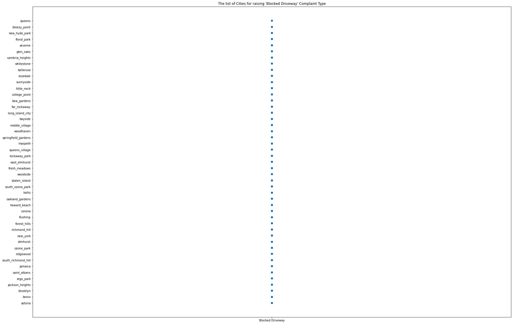

```python
plt.figure(figsize=(30,20))
plt.scatter(dataGrouped['Complaint Type'],dataGrouped['City'])
plt.title("The list of Cities for raising 'Blocked Driveway' Complaint Type")
plt.show()
```

# Conclusion #1

```
- Based on the above visualization, Blocked Driveway Complaint Type is ranked first for Number of Complaints
- And Illegal Parking Complaint Type is ranked in second place
```

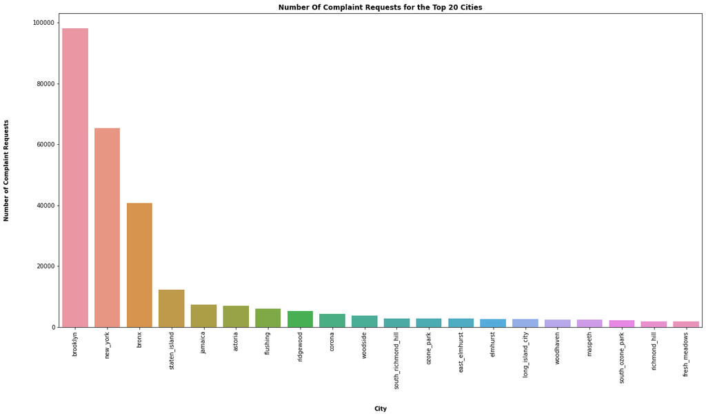

```python
# Number of Requests for the Top 20 Cities
top20_cities = df['City'].value_counts().head(20)
top20 = top20_cities.index
txt={'weight':'bold'}
plt.figure(figsize=(20,10))
sns.countplot(x='City',data=df[df.City.isin(top20)], order=top20)
plt.title("Number Of Complaint Requests for the Top 20 Cities",fontdict=txt)
plt.xlabel('City',fontdict=txt,labelpad=30)
plt.xticks(rotation=90)
plt.ylabel('Number of Complaint Requests',fontdict=txt,labelpad=40)
plt.show()
```

# Conclusion #2

#### Number of Complaints by City

```
- The city of Brooklyn is ranked 1st for the Number of Complaint Request
```

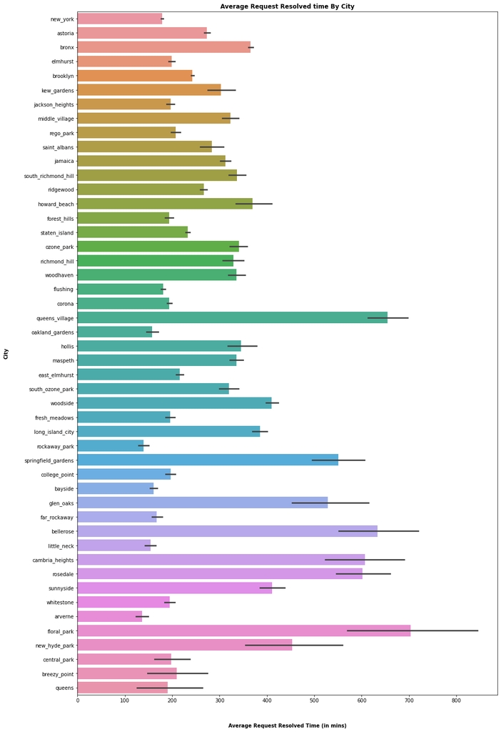

```python
# Average Response time for the Complaints
dsply = df[['City','Closing_time_min']]
cal =dsply.groupby('City')['Closing_time_min'].mean().to_frame()
cal = cal.sort_values('Closing_time_min')
cal['City'] = cal.index
txt={'weight':'bold'}
plt.figure(figsize=(15,25))
sns.barplot(y='City',x='Closing_time_min',data=dsply)
plt.title("Average Request Resolved time By City",fontdict=txt)
plt.ylabel("City",fontdict=txt,labelpad=30)
plt.xlabel("Average Request Resolved Time (in mins)",fontdict=txt,labelpad=40)
plt.show()
```

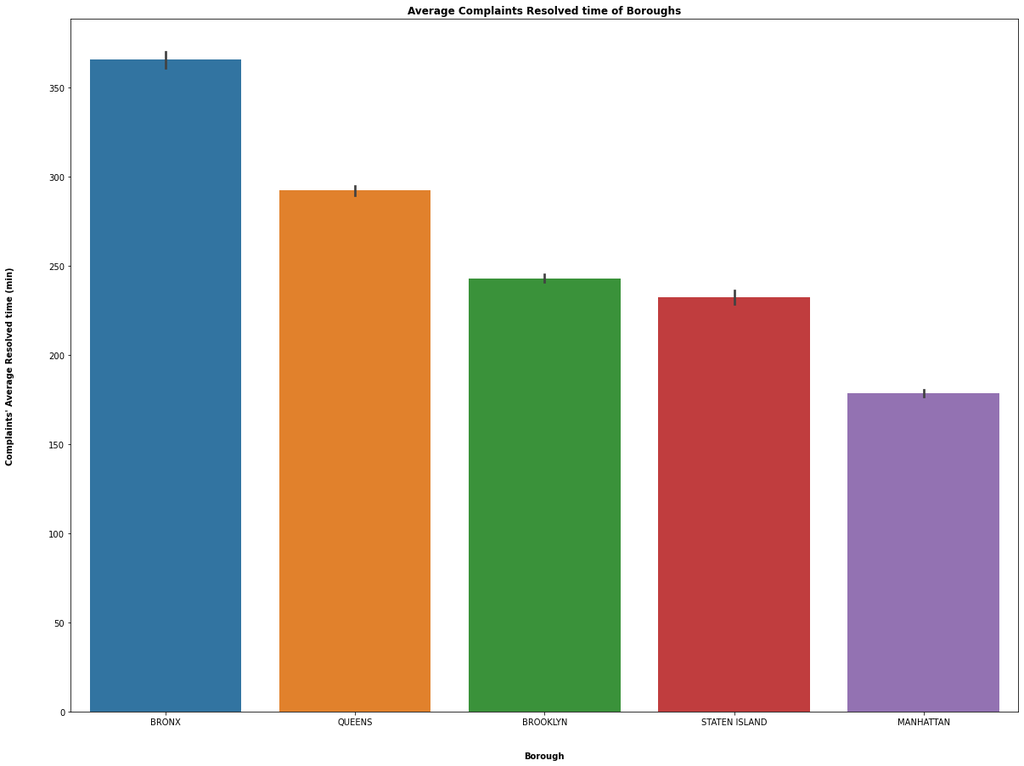

```python
# Average response time of Boroughs
txt={'weight':'bold'}
plt.figure(figsize=(20,15))
sns.barplot(x='Borough',y='Closing_time_min',data=df,order=['BRONX','QUEENS','BROOKLYN','STATEN ISLAND','MANHATTAN'])
plt.title("Average Complaints Resolved time of Boroughs",fontdict=txt)
plt.xlabel("Borough",fontdict=txt,labelpad=30)
plt.ylabel("Complaints' Average Resolved time (min)",fontdict=txt,labelpad=40)
plt.show()
```

# Conclusion #3

##### Responce time for the Complaints (Average vs Maximum) and (Minimum vs Maximum)

```
    - When Flora Park scored a maximum number of respond time for the complaint request, Arverne scored minimum
    - Based on the average respond time of the complaint request, Bronx is ranked 1st with maximum and Manhattan scored
      minimum
```

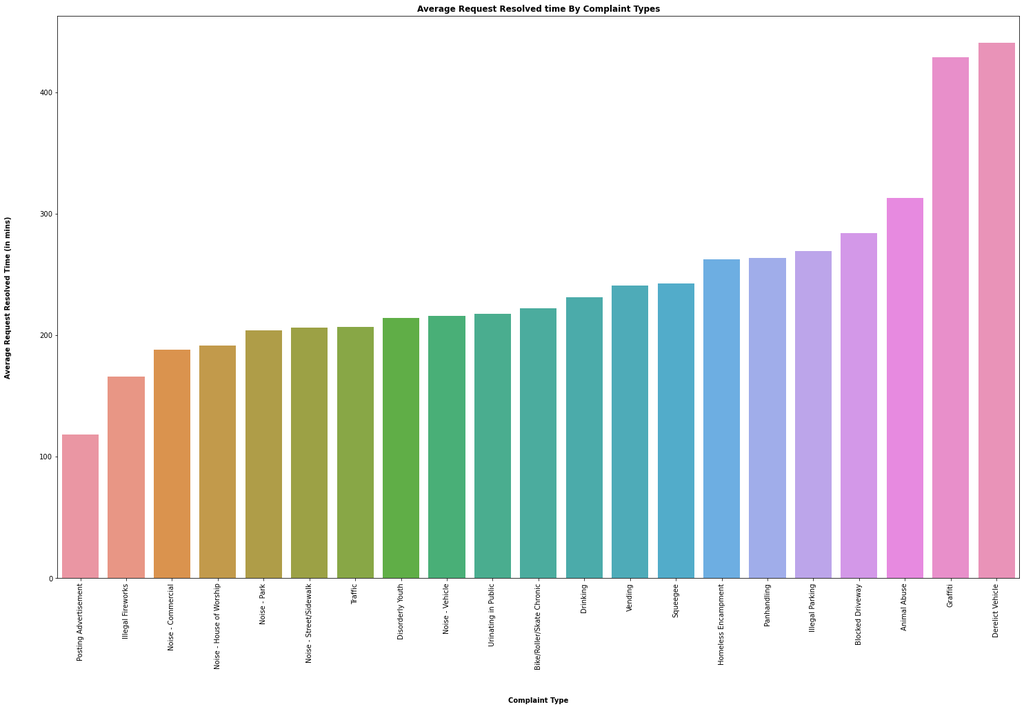

```python
# Average Response time for the Complaints
dsply2 = df[['Complaint Type','Closing_time_min']]
cal2 =dsply2.groupby('Complaint Type')['Closing_time_min'].mean().to_frame()
cal2 = cal2.sort_values('Closing_time_min')
cal2['Complaint Type'] = cal2.index
txt={'weight':'bold'}
plt.figure(figsize=(25,15))
sns.barplot(x='Complaint Type',y='Closing_time_min',data=cal2)
plt.title("Average Request Resolved time By Complaint Types",fontdict=txt)
plt.xlabel("Complaint Type",fontdict=txt,labelpad=40)
plt.ylabel("Average Request Resolved Time (in mins)",fontdict=txt,labelpad=40)
plt.xticks(rotation=90)
plt.show()
```

# Conclusion #4

##### Which Complaints are Responded quick & which ones are not

```
    - Derelict Vehicle & Posting Advertistment complaints scored the slowest and quickest respond time. In this case,
      The Respond time for Derelict Vehicle complaints was slower and the Posting Advertistment was Fastest
```

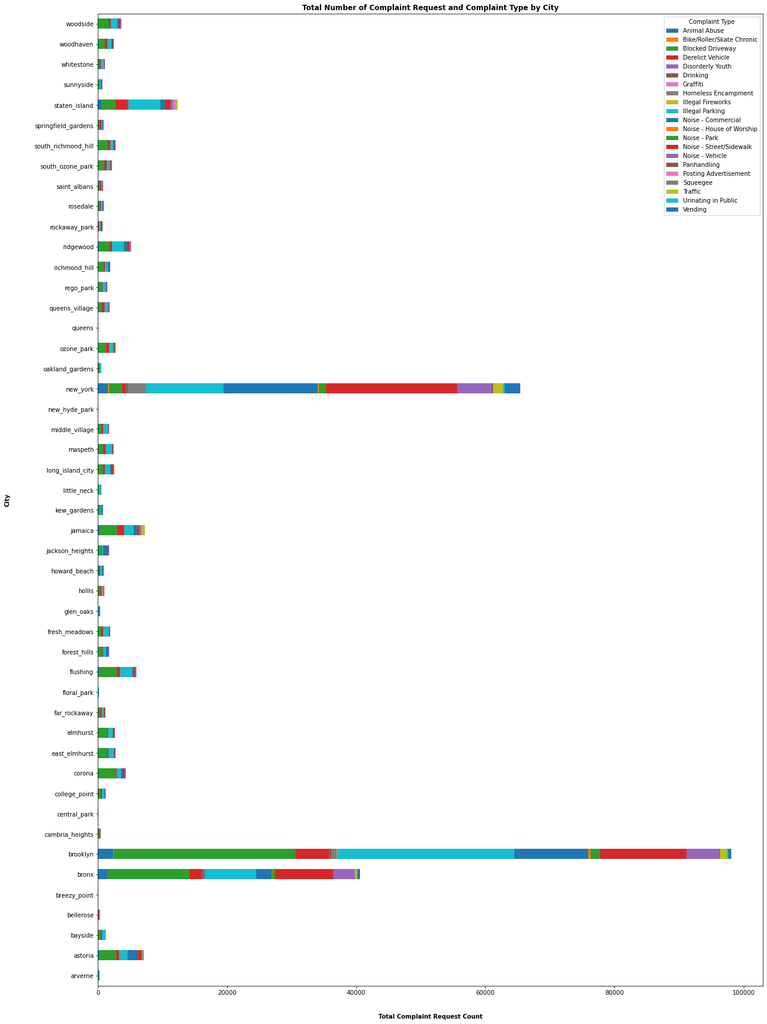

```python
# The Complaint Types and number of compalint requests by City
complaintType_by_city = pd.crosstab(index=df['City'],columns=df['Complaint Type'])
txt={'weight':'bold'}
plt.figure(figsize=(25,15))
complaintType_by_city.plot(kind='barh',figsize=(20,30),stacked=True)
plt.title("Total Number of Complaint Request and Complaint Type by City",fontdict=txt)
plt.xlabel("Total Complaint Request Count",fontdict=txt,labelpad=30)
plt.ylabel("City",fontdict=txt,labelpad=40)
plt.show()
```

# Conclusion #5

##### Number of Complaints Requests by Complaint Type

```
   - For both Number of Complaint Request and Complaint Types, Brooklyn scored the maximum number than the other cities.
```